# Data 607 Final Project

Rathish Sasidharan

5/18/2021

## Overview

As part of this project , I will analyzing the Netflix TV shows and movie data and will try to answer the below research questions. The dataset consists of TV shows and movies available on Netflix as of 2021. The dataset is collected from Flixable which is a third-party Netflix search engine.

### Research question

As part of this project , we perform the following analysis on the Netflix content (movies and TV shows)

1. Analyze the percentage of TV Shows and Movies in Netflix?
2. Analyze the trends of TV Shows and Movies over the years?
3. Find the top 3 countries with most number of Movies and TV Shows?
4. What is the distribution of “duration of movies” and the “seasons in TV Shows” ?  
   Analyze whether the distributions are normal.
5. Analyze is there any relationship between the Release Year and Duration of Movies?  
   Perform a regression analysis.
6. Analyze is there a relationship between the Release Year and the number of seasons?  
   Perform a regression analysis.
7. Is there any relationship between the Country and Duration of Movies ?  
   Perform a variance analysis (AOV)
8. Is there a relationship between the Genre and Duration of Movies ?  
   Perform a variance analysis (AOV)?

## About the Data

There are 7787 observations in the dataset which is either a movie or a TV show and the below 12 variables describes the data:

show_id - Unique ID for Movie / TV Show  
type - Identifier - A Movie or TV Show  
title - Title of the Movie / TV Show  
director - Director of the Movie  
cast - Actors involved in the movie / show  
country - Country where the movie / show was produced  
date_added - Date it was added on Netflix  
release_year - Actual Release year of the move / show  
rating - TV Rating of the movie / show  
duration - Total Duration - in minutes or number of seasons  
listed_in - Genres  
description - The summary description

### Type of study

This is an observational data

### Data Source

The data is collected from below [website](https://www.kaggle.com/shivamb/netflix-shows)

## Relevant summary statistics

### 1. Load Required Packages

```r
library(tidyverse)
library(dplyr)
library(nortest)
```

### 2. Data Preparation and Clean up

```r
data <- read.csv("https://raw.githubusercontent.com/rathish-ps/Data607-Assignment/main/netflix_titles.csv")

data <- data %>%
  mutate(country = replace(country, country ==  "", NA ))

data$country[data$country==""]<-NA
data_without_countryNA <- data %>% drop_na()

data$director <- iconv(data$director, 'utf-8', 'ASCII//TRANSLIT', sub='')
data$title <- iconv(data$title, 'utf-8', 'ASCII//TRANSLIT', sub='')
data$cast <- iconv(data$cast, 'utf-8', 'ASCII//TRANSLIT', sub='')
data$description <- iconv(data$description, 'utf-8', 'ASCII//TRANSLIT', sub='')
#data$date_added <- parse_date_time(data$date_added, orders = "mdy")
data$date_added <-as.Date(strptime(data$date_added, format = "%d-%b-%y"))
```

### 3. Data Analysis

#### 3.1 Analyse the percentage of TV Shows and Movies in Netflix?

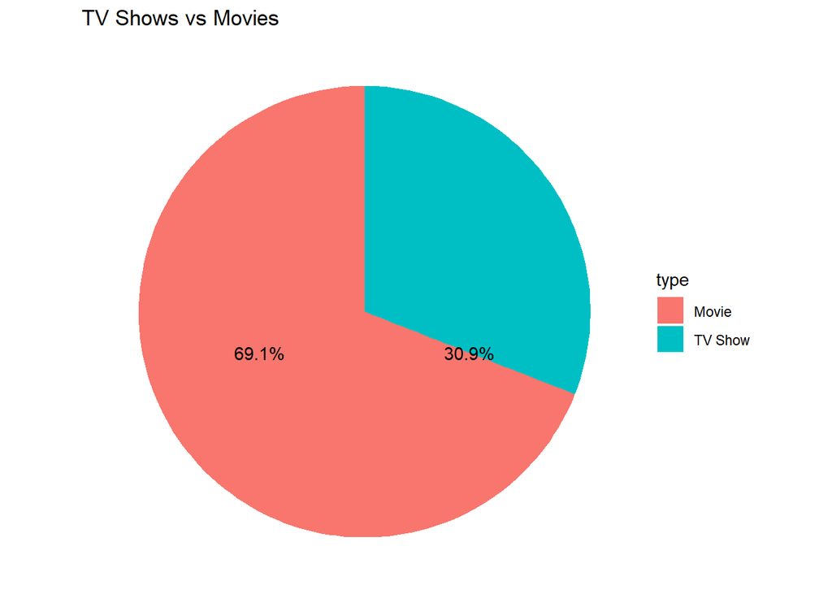

```r
data1<- data %>%
  group_by(type) %>%
  summarise(Total = n()) %>%
  mutate( Percentage =Total/sum(Total)*100 )


ggplot(data=data1)+
  geom_bar(aes(x="", y=Total, fill=type), stat="identity", width = 1)+
  coord_polar("y", start=0)+
  ggtitle("TV Shows vs Movies") +
  theme_void()+
  geom_text(aes(x=1, y = Total, label=sprintf("%0.1f%s", round(Percentage, digits = 3),"%")))
```

From the Graph we could see that 69,1% of the content from Netflix are movies and the 30.9% are TV Shows

#### 3.2 Analyse the trends of TV Shows and Movies over the years?

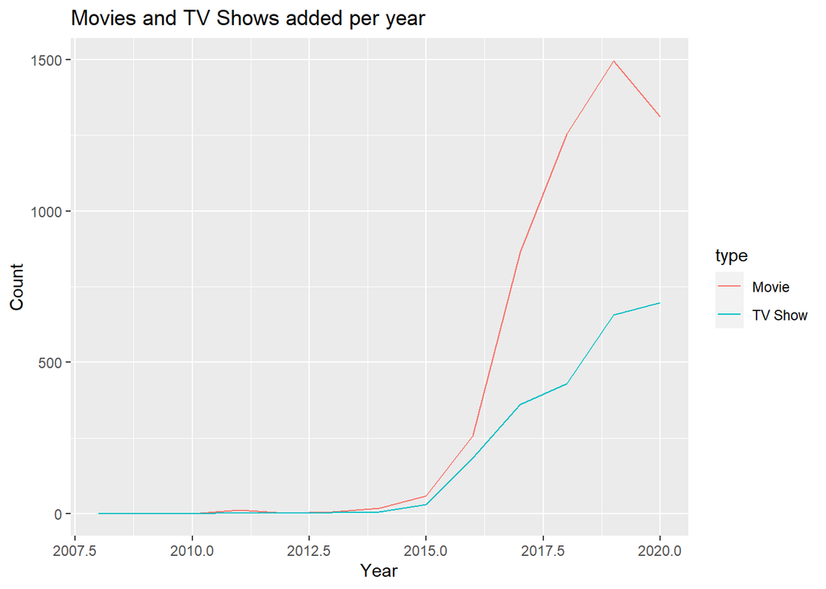

```r
data %>% filter(as.numeric(format(date_added,'%Y'))<2021) %>%
    group_by(year=as.numeric(format(date_added,'%Y')), type) %>%
    count()%>%
  ggplot() + geom_line(aes(x = year, y = n, group = type, color = type)) +
  ggtitle("Movies and TV Shows added per year") +
  labs(x = "Year", y = "Count")
```

From the Graph we could see that from 2015 on wards Netflix started adding more TV shows and Movies.

#### 3.3 Top 3 countries with most number of Movies and TV Shows

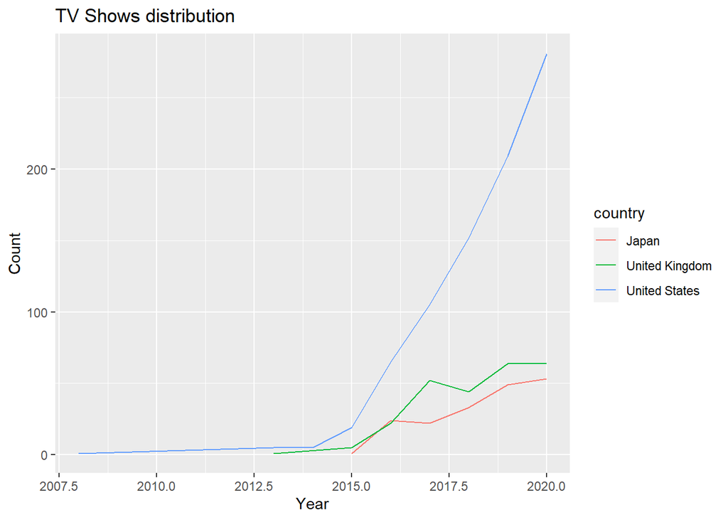

```r
data_show<-data%>% filter(type =='TV Show')

data_show1<-data_show%>%mutate(durationNum =as.numeric(strsplit(duration,"Seasons")))
data_show2<-data_show1%>% filter(is.na(durationNum))%>%mutate(durationNum =as.numeric(strsplit(duration,"Season")))

data_show1<-data_show1%>%filter(!is.na(durationNum))

data_show<-rbind(data_show1,data_show2)

# find the tv shows by country

data4 <- data_show %>%filter(!is.na(country)) %>%
mutate(country = strsplit(as.character(country), ", ")) %>%
unnest(country) %>%
group_by(country,durationNum)

summary4 <- data4  %>%
  group_by(country) %>%
  summarise(Total = n())

 summary4<-summary4[order(summary4$Total, decreasing = TRUE), ]
 summary4<- summary4%>%top_n(3)
  # we are considering only top 3 countries by movie
  countriesTvShow <-summary4$country
  #countriesTvShow



  summaryTopTvShow <- data4  %>%filter(!is.na(date_added))%>%mutate( year_added =as.numeric(format(date_added,'%Y') ))%>%
  group_by(country,year_added) %>%  summarise(Total = n())

 summaryTopTvShow<- summaryTopTvShow %>%filter(country %in% countriesTvShow)


 summaryTopTvShow %>% filter(year_added < 2021) %>%
   ggplot() + geom_line(aes(x = year_added, y = Total, group = country, color = country)) +
  ggtitle("TV Shows distribution") +
  labs(x = "Year", y = "Count")
```

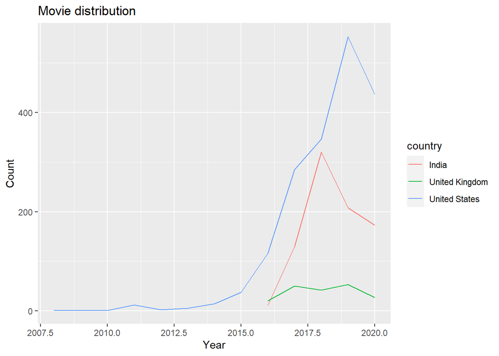

```r
# for movies

data_movie<-data%>% filter(type =='Movie')

data_movie<-data_movie%>%mutate(durationNum =as.numeric(strsplit(duration,"min")))
  data2 <- data_movie %>%
  mutate(country = strsplit(as.character(country), ", ")) %>%
  unnest(country) %>%
  group_by(country,durationNum)

 summary2 <- data2 %>% filter(!is.na(country)) %>%
  group_by(country) %>%
  summarise(Total = n())

  summary2<-summary2[order(summary2$Total, decreasing = TRUE), ]
  summary2<- summary2%>%top_n(10)
  summary6<- summary2%>%top_n(3)
  countriesMovies <-summary6$country
 # countriesMovies


   summaryTopMoies <- data_movie %>%filter(!is.na(date_added))%>%mutate( year_added =as.numeric(format(date_added,'%Y') ))%>%
  group_by(country,year_added) %>%  summarise(Total = n())

 summaryTopMoies<- summaryTopMoies %>%filter(country %in% countriesMovies)

  summaryTopMoies %>% filter(year_added < 2021) %>%
   ggplot() + geom_line(aes(x = year_added, y = Total, group = country, color = country)) +
  ggtitle("Movie distribution") +
  labs(x = "Year", y = "Count")
```

#### 3.4 What is the distribution of “duration of movies” and the “seasons in TV Shows” ?

**Analyze the duration of movies**

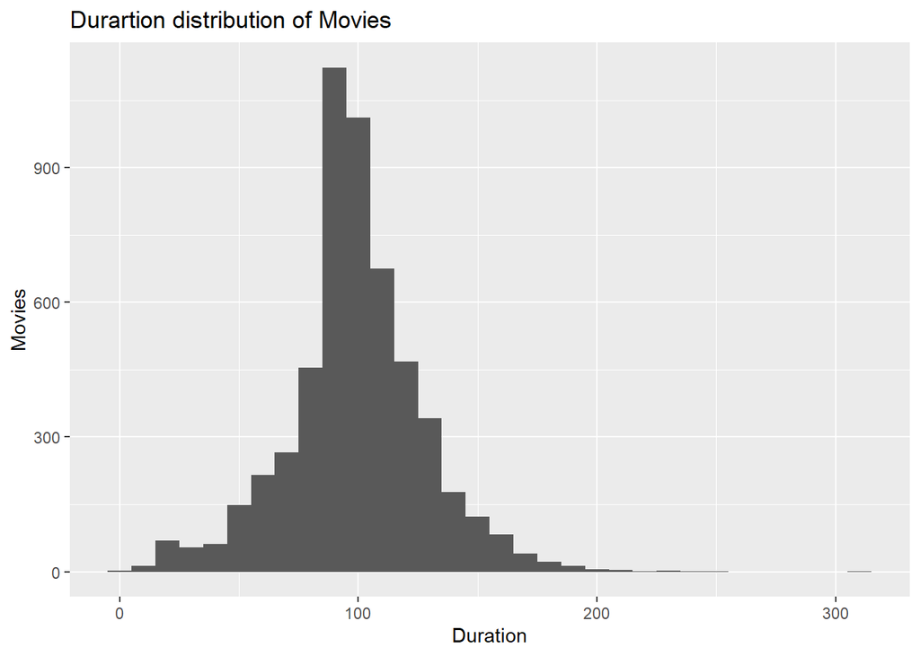

```r
data_movie<-data%>% filter(type =='Movie')

data_movie<-data_movie%>%mutate(durationNum =as.numeric(strsplit(duration,"min")))

ggplot(data_movie) +
  geom_histogram(binwidth = 10, aes(x = durationNum)) +
  labs(title = 'Durartion distribution of Movies')+
  labs(x = "Duration", y = "Movies")
```

```r
#check whether it follows a normal distribution?
ad.test(data_movie$durationNum)
```

```
##
##  Anderson-Darling normality test
##
## data:  data_movie$durationNum
## A = 47.076, p-value < 2.2e-16
```

Since the p-value < 0.05 means the time duration of movies are not following a normal distribution

**Analyze the number of seasons in TV Shows**

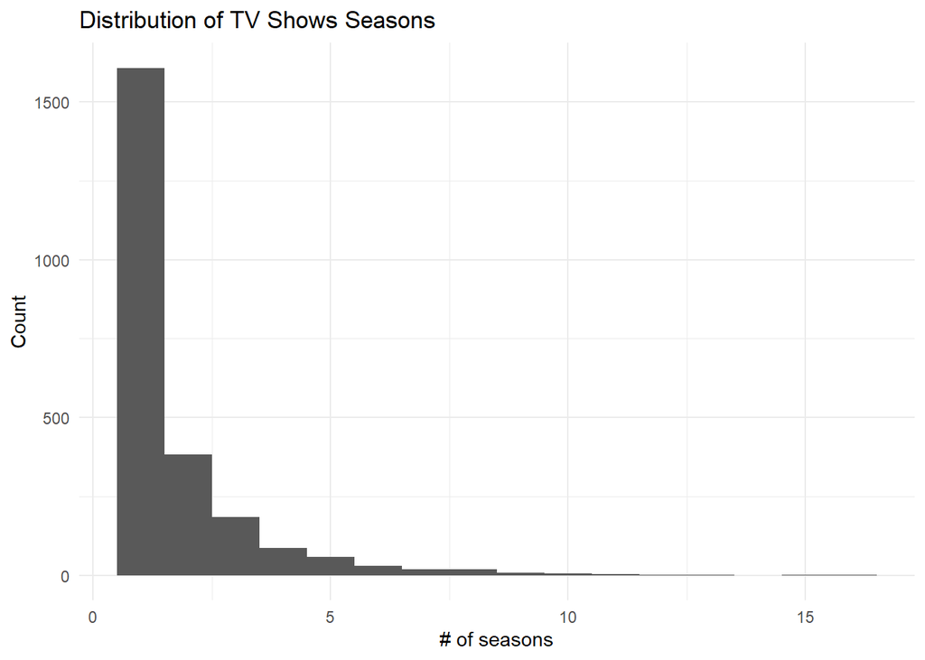

```r
data_show<-data%>% filter(type =='TV Show')

data_show1<-data_show%>%mutate(durationNum =as.numeric(strsplit(duration,"Seasons")))
data_show2<-data_show1%>% filter(is.na(durationNum))%>%mutate(durationNum =as.numeric(strsplit(duration,"Season")))

data_show1<-data_show1%>%filter(!is.na(durationNum))

data_show<-rbind(data_show1,data_show2)

ggplot(data_show) +
  geom_histogram(binwidth = 1, aes(x = durationNum)) +
  labs(title = 'Distribution of TV Shows Seasons')+
  labs(x = "# of seasons", y = "Count") +
  theme_minimal()
```

```r
ad.test(data_show$durationNum)
```

```
##
##  Anderson-Darling normality test
##
## data:  data_show$durationNum
## A = 386.27, p-value < 2.2e-16
```

From the histogram it is clear most of the TV shows has only one season and the distribution is right skewed. Also from the p-value (2.2e-16 ) it is clear the number of seasons doesn’t follow a normal distribution.

#### 3.5 Analyse is there any relationship between the Release Year and Duration of Movies?

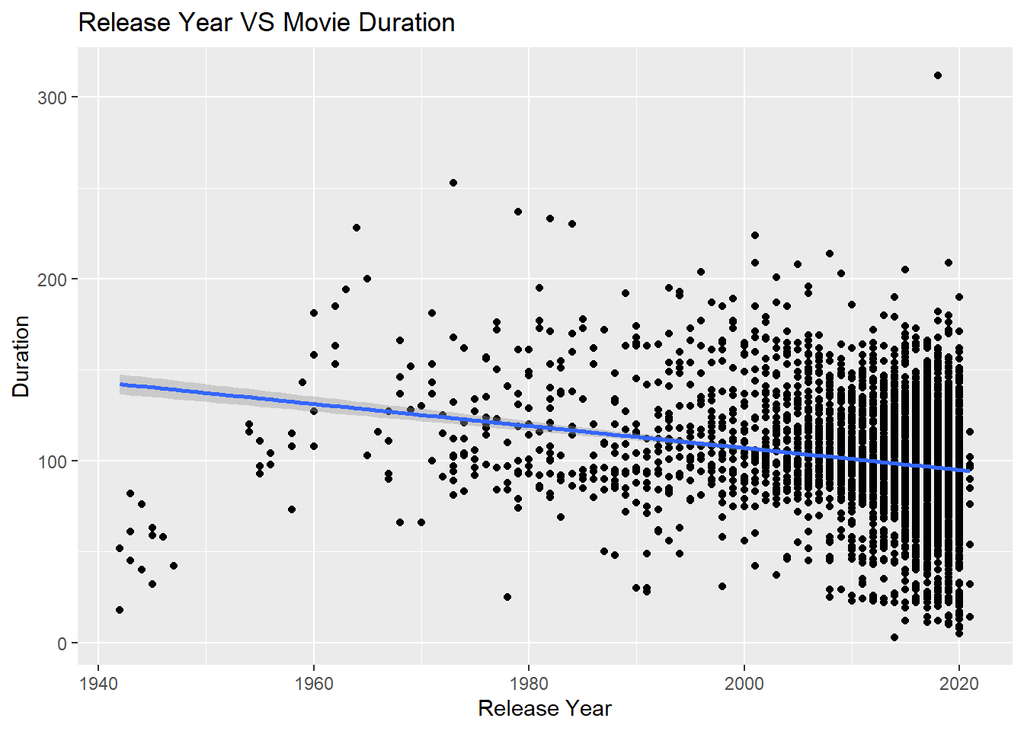

```r
data_movie %>%
ggplot( aes(x = release_year,
           y = durationNum)) +
  geom_point() +
  geom_smooth(method = "lm")+
  ggtitle("Release Year VS Movie Duration") +
  labs(x = "Release Year", y = "Duration")
```

```r
cor.test(data_movie$release_year,data_movie$durationNum)
```

```
##
##  Pearson's product-moment correlation
##
## data:  data_movie$release_year and data_movie$durationNum
## t = -15.347, df = 5375, p-value < 2.2e-16
## alternative hypothesis: true correlation is not equal to 0
## 95 percent confidence interval:
##  -0.2303589 -0.1791420
## sample estimates:
##        cor
## -0.2048907
```

Based on that correlation coefficient, linear relationship between the two variables is low.

```r
lm1 <- lm(release_year~ durationNum, data =data_movie)
#summary(lm1)$r.squared
summary(lm1)
```

```
##
## Call:
## lm(formula = release_year ~ durationNum, data = data_movie)
##
## Residuals:
##     Min      1Q  Median      3Q     Max
## -76.562  -1.150   2.712   4.920  19.840
##
## Coefficients:
##               Estimate Std. Error t value Pr(>|t|)
## (Intercept)  2.020e+03  4.672e-01 4323.15   <2e-16 ***
## durationNum -6.940e-02  4.522e-03  -15.35   <2e-16 ***
## ---
## Signif. codes:  0 '***' 0.001 '**' 0.01 '*' 0.05 '.' 0.1 ' ' 1
##
## Residual standard error: 9.459 on 5375 degrees of freedom
## Multiple R-squared:  0.04198,    Adjusted R-squared:  0.0418
## F-statistic: 235.5 on 1 and 5375 DF,  p-value: < 2.2e-16
```

From the analysis it is clear that the correlation coefficient(-0.20) is low and the R-square is 4.1 % meaning there is no linear relation exist between release year and movie duration.

#### 3.6 Analyse is there a relationship between the Release Year and the number of seasons?

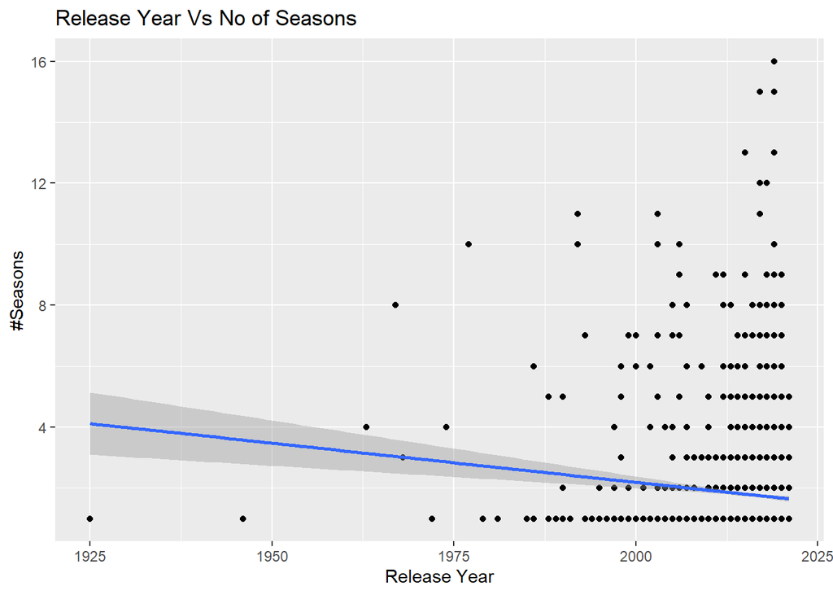

```r
data_show %>%
ggplot( aes(x = release_year,
           y = durationNum)) +
  geom_point() +
  geom_smooth(method = "lm")+

  ggtitle("Release Year Vs No of Seasons") +
  labs(x = "Release Year", y = "#Seasons")
```

```r
cor(data_show$release_year,data_show$durationNum)
```

```
## [1] -0.0912783
```

Based on that correlation coefficient, linear relationship between the two variables is low (-0.09)

```r
lm1 <- lm(release_year~ durationNum, data =data_show)
summary(lm1)
```

```
##
## Call:
## lm(formula = release_year ~ durationNum, data = data_show)
##
## Residuals:
##     Min      1Q  Median      3Q     Max
## -91.443  -0.795   1.557   2.881   7.416
##
## Coefficients:
##               Estimate Std. Error   t value Pr(>|t|)
## (Intercept) 2016.76694    0.17195 11728.969  < 2e-16 ***
## durationNum   -0.32391    0.07201    -4.498 7.19e-06 ***
## ---
## Signif. codes:  0 '***' 0.001 '**' 0.01 '*' 0.05 '.' 0.1 ' ' 1
##
## Residual standard error: 5.642 on 2408 degrees of freedom
## Multiple R-squared:  0.008332,   Adjusted R-squared:  0.00792
## F-statistic: 20.23 on 1 and 2408 DF,  p-value: 7.188e-06
```

From the analysis it is clear that the correlation coefficient(-0.09) is low and the R-square is .8 % meaning there is no linear relation exist between release year and number of seasons.

#### 3.7 Is there any relationship between the Country and Duration of Movies?

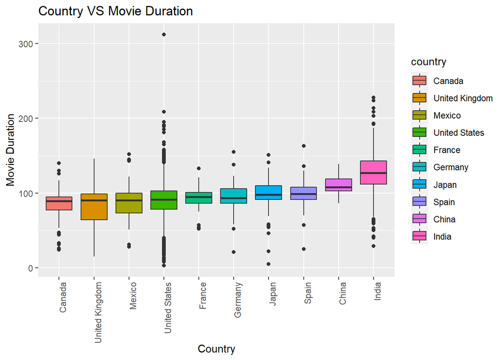

```r
 data2 <- data_movie %>%
  mutate(country = strsplit(as.character(country), ", ")) %>%
  unnest(country) %>%
  group_by(country,durationNum)

 summary2 <- data2 %>% filter(!is.na(country)) %>%
  group_by(country) %>%
  summarise(Total = n())

  summary2<-summary2[order(summary2$Total, decreasing = TRUE), ]
  summary2<- summary2%>%top_n(10)

  # we are considering only top 10 countries by movie
  countries <-summary2$country

  data2<- data_movie %>%
filter(country %in% countries)

data2 %>%
  mutate(country = reorder(country, durationNum, FUN = mean)) %>%
  ggplot(aes(country, durationNum, fill = country)) +
  geom_boxplot() +
  theme(axis.text.x = element_text(angle = 90, hjust = 1)) +
  ggtitle("Country VS Movie Duration") +
  labs(x = "Country", y = "Movie Duration")
```

```r
data2 %>%
filter(country %in% countries)  %>%
group_by(country) %>%
  summarise(
    size = n(),
    mean = mean(durationNum, na.rm = TRUE),
    sd = sd(durationNum, na.rm = TRUE)
  )
```

```
## # A tibble: 10 x 4
##    country         size  mean    sd
##    <chr>          <int> <dbl> <dbl>
##  1 Canada           118  82.4  24.6
##  2 China             21 110.   12.5
##  3 France            69  93.2  16.3
##  4 Germany           42  94.0  23.3
##  5 India            852 127.   25.5
##  6 Japan             69  96.2  26.3
##  7 Mexico            65  86.8  23.9
##  8 Spain             89  99.9  17.3
##  9 United Kingdom   193  84.4  24.4
## 10 United States   1850  89.4  25.3
```

```r
# Compute the analysis of variance
anova_country <- aov(durationNum ~ country, data = data2)
# Summary of the analysis
summary(anova_country)
```

```
##               Df  Sum Sq Mean Sq F value Pr(>F)
## country        9  948518  105391   170.4 <2e-16 ***
## Residuals   3358 2076567     618
## ---
## Signif. codes:  0 '***' 0.001 '**' 0.01 '*' 0.05 '.' 0.1 ' ' 1
```

Hypothesis: the time duration of movies are the same among the countries.  
The P-Value ( 2e-16) is very small (< 0.05) and therefore we reject the null hypothesis.  
It means that the difference of time duration across the countries selected is statistically significant.

#### 3.8 Is there a relationship between the Genre and Duration of Movies?

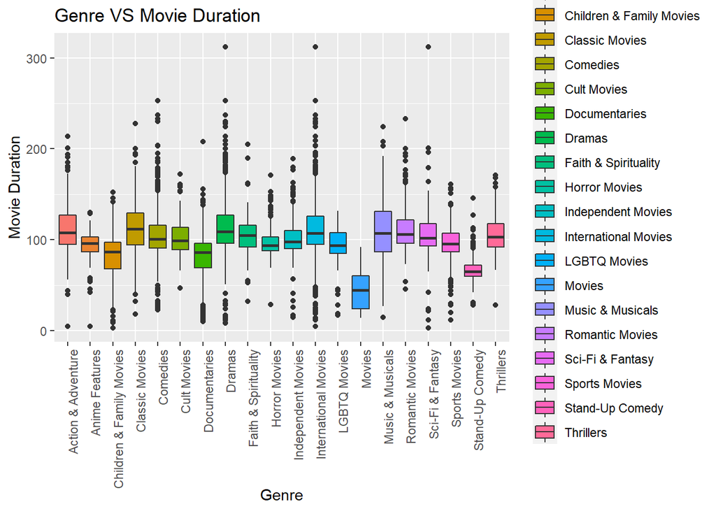

```r
data3 <- data_movie %>%
  mutate(listed_in = strsplit(as.character(listed_in), ", ")) %>%
  unnest(listed_in) %>%
  group_by(listed_in,durationNum)

data3 %>%
  mutate(listed_in = reorder(listed_in, durationNum, FUN = mean)) %>%
  ggplot(aes(listed_in, durationNum, fill = listed_in)) +
  geom_boxplot() +
  theme(axis.text.x = element_text(angle = 90, hjust = 1)) +
  ggtitle("Genre VS Movie Duration") +
  labs(x = "Genre", y = "Movie Duration")
```

```r
data3 %>%
group_by(listed_in) %>%
  summarise(
    size = n(),
    mean = mean(durationNum, na.rm = TRUE),
    sd = sd(durationNum, na.rm = TRUE)
  )
```

```
## # A tibble: 20 x 4
##    listed_in                 size  mean    sd
##    <chr>                    <int> <dbl> <dbl>
##  1 Action & Adventure         721 113.   24.9
##  2 Anime Features              57  91.2  21.8
##  3 Children & Family Movies   532  79.7  27.6
##  4 Classic Movies             103 116.   37.4
##  5 Comedies                  1471 105.   24.2
##  6 Cult Movies                 59 105.   25.1
##  7 Documentaries              786  81.4  23.7
##  8 Dramas                    2106 113.   25.3
##  9 Faith & Spirituality        57 105.   29.3
## 10 Horror Movies              312  97.5  15.7
## 11 Independent Movies         673 101.   18.2
## 12 International Movies      2437 111.   26.5
## 13 LGBTQ Movies                90  94.0  21.8
## 14 Movies                      56  45.9  21.6
## 15 Music & Musicals           321 109.   32.3
## 16 Romantic Movies            531 111.   21.8
## 17 Sci-Fi & Fantasy           218 106.   27.9
## 18 Sports Movies              196  95.4  24.4
## 19 Stand-Up Comedy            329  67.1  13.0
## 20 Thrillers                  491 107.   19.6
```

```r
# Compute the analysis of variance
anova_genre <- aov(durationNum ~ listed_in, data = data3)
# Summary of the analysis
summary(anova_genre)
```

```
##                Df  Sum Sq Mean Sq F value Pr(>F)
## listed_in      19 1816985   95631   158.6 <2e-16 ***
## Residuals   11526 6948282     603
## ---
## Signif. codes:  0 '***' 0.001 '**' 0.01 '*' 0.05 '.' 0.1 ' ' 1
```

Hypothesis: the time duration of the movies are the same among the genres.

The P-Value(2e-16) is very small (< 0.05) and therefore we reject the null hypothesis. It means that at least two of the means are different, the difference in movie duration between the genres is statistically significant.

## 4 Summary

Analyzed the Netflix content data using different plots like scatter plots, line chart, boxplot and bar charts. We found that 69.1% of the content from Netflix are movies and the 30.9% are TV Shows

The top 3 countries creating TV Show content for Netflix are United States, United Kingdom and Japan and top 3 countries creating TV Movie content are United States, India and United Kingdom.

There is no linear relationship between time duration in the Movies/ No of seasons in TV Shows and the release year. From our analysis We noticed that correlation coefficient and R-square values are low.

From the variance analysis (AOV),the difference of time duration of movies across the countries is statistically significant. The same happens with the genres